# Homework6_209

## Due Friday 11/08 at 10pm.

This assignment has 25 points possible. Your score will be calculated out of 22 points and scaled to be out of 5 points.

You may use the solutions to answer your questions but you may not just copy them. Put them in your own words.

# Question 1 – Sex Equality (4 pts)

The General Social Survey asked a random sample of 1,390 Americans the following question: “On the whole, do you think it should or should not be the government’s responsibility to promote equality between men and women?” 82% of the respondents said it “should be”. At a 95% confidence level, this sample has 2% margin of error. Based on this information, determine if the following statements are true or false, and explain your reasoning. (NORC 2016)

**Part A**: We are 95% confident that 80% to 84% of Americans in this sample think it’s the government’s responsibility to promote equality between men and women.

```r
# False. We are 100% confident the 'sample proportion' is within the CI because we defined it to be the middle
```

**Part B**: We are 95% confident that 80% to 84% of all Americans think it’s the government’s responsibility to promote equality between men and women.

```r
# True. This is just the interpretation of the CI
```

**Part C**: If we considered many random samples of 1,390 Americans, and we calculated 95% confidence intervals for each, 95% of these intervals would include the true population proportion of Americans who think it’s the government’s responsibility to promote equality between men and women.

```r
# True. This is what '95% confidence' means
```

**Part D**: In order to decrease the margin of error to 1%, we would need to quadruple (multiply by 4) the sample size.

```r
# True
1.96 * sqrt(.82 * (1-.82)/1390)
```

```
## [1] 0.02019723
```

```r
1.96 * sqrt(.82 * (1-.82)/(4*1390))
```

```
## [1] 0.01009862
```

# Question 2 – Proof of COVID-19 vaccination (6 pts)

In the US, businesses and schools shut down due to the COVID-19 pandemic in March 2020, and a vaccine became publicly available for the first time in April 2021. That month, a Gallup poll surveyed a random sample of 3,731 US adults, asking how they felt about the COVID-19 vaccine requirement for air travel. The poll found that 57% said they would favor it. (Gallup 2021b)

**Part A**: Describe the population parameter of interest.

```r
# p = population proportion of all US adults that favor the vaccine requirement
```

**Part B**: Construct a 95% confidence interval for the proportion of US adults who favored requiring proof of COVID-19 vaccination for travel by airplane. (Show work and final value)

```r
# n = 3731, p_hat = .57
.57 - 1.96 * sqrt(.57 * (1-.57) / 3731)
```

```
## [1] 0.554114
```

```r
.57 + 1.96 * sqrt(.57 * (1-.57) / 3731)
```

```
## [1] 0.585886
```

**Part C**: Interpret the confidence interval.

```r
# We are 95% confidence the population proportion of all US adults that favor the vaccine requirement is between .554 and .586
```

**Part D**: Without doing any calculations, describe what would happen to the confidence interval if we decided to use a higher confidence level.

```r
# The interval gets wider. (value of z* gets bigger)
```

**Part E**: Without doing any calculations, describe what would happen to the confidence interval if we used a larger sample.

```r
# The interval gets narrower. (dividing by bigger number in the SE)
```

# Question 3 – Is Yawning Contagious? (3 pts)

Suppose we are interested in estimating the difference in yawning rates between the control and treatment groups using a confidence interval. Explain why we cannot construct such an interval using the normal approximation. What might go wrong if we constructed the confidence interval despite this problem?

```r
# Pick one group to be group 1 (I'm picking treatment group)
```

```r
# Random Sample (not met)
# n1*P-hat1 = # of yawns trt grp = 10 >= 10 (met)
# n1*(1-P-hat1) = # of 'not yawns' trt grp = 24 >= 10 (met)
# n2*P-hat2 = # of yawns ctrl grp = 4 (not met)
# n2*(1-P-hat2) = # of 'not yawns' ctrl grp = 12 >= 10 (met)
```

```r
# If we construct a CI with the conditions not met, the confidence will actually be less than we wanted. Also there is no random sample, so the sample is probably biased.
```

# Question 4 – Sleep deprivation (5 pts)

A CDC report on sleep deprivation rates shows that the proportion of California residents who reported insufficient rest or sleep during each of the preceding 30 days is 8.0%, while this proportion is 8.8% for Oregon residents. These data are based on simple random samples of 11,545 California and 4,691 Oregon residents.

Construct a 90% confidence interval for the difference in proportions (Oregon - California) and interpret the interval in context.

```r
# p-hat_oregeon = .088, n_oregon = 4691
# p-hat_california = .08, n_california = 11545
```

```r
(.088 - .08) - 1.645 * sqrt(.088*(1.-0.088)/4691 + .08*(1-.08)/11545)
```

```
## [1] 2.835651e-05
```

```r
(.088 - .08) + 1.645 * sqrt(.088*(1.-0.088)/4691 + .08*(1-.08)/11545)
```

```
## [1] 0.01597164
```

```r
# We are 90% confident the population proportion of all Oregon residents that reported insufficient rest or sleep during the last 30 days is between 0 and .016 higher than for California
```

# Question 5 – Rainbow Trout - Bootstrapping (7 pts)

This is a continuation of the Rainbow Trout problem on HW5. We will use bootstrapping to make a confidence interval instead of the t-distribution. We will generate a sample that matches the info provided in that question. Specifically we are looking at the sinking net info. We will use this generated sample as a ‘new’ dataset because we don’t have the original sample data in its entirety.

#### Sinking Net Fish

The average length (mm) for the fish caught in the Sinking Net was 254.972 with a standard deviation of 73.619. Sample size = 71

```r
library(ggplot2)
library(dplyr)

theme_set(theme_bw())

## Better histograms
gh <- function(bins = 10) {
  geom_histogram(color = 'black', fill = 'gray80', bins = bins)
}

## Bootstrapping function
bootstrap <- function(x, statistic, n = 1000L) {
  bs <- replicate(n, {
    sb <- sample(x, replace = TRUE)
    statistic(sb)
  })
  data.frame(Sample = seq_len(n),
             Statistic = bs)
}

set.seed(8675309)
# generate new sample
data_sink = rnorm(71, mean=254.972, sd=73.619)
```

**Part A**: Make a bootstrap distribution for the mean length of all fish caught with the sinking net using 1000 samples (use the `gh()` function from above).

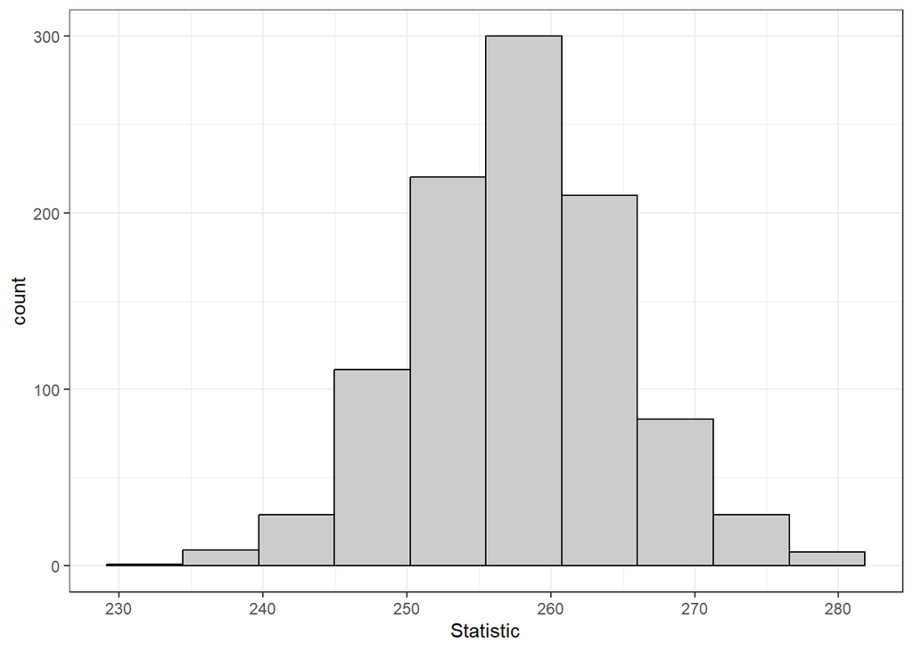

```r
mean_boot <- bootstrap(data_sink, mean, n=1000)
ggplot(mean_boot, aes(x=Statistic)) + gh(bins=10)
```

**Part B**: Use the `quantile()` function and the bootstrap distribution to make a 90% CI for the mean

```r
quantile(x=mean_boot$Statistic, probs=c(.05, .95))
```

```
##       5%      95%
## 245.9506 269.8221
```

**Part C**: Suppose the true mean length of fish caught with the *floating net* is 300mm. According the bootstrap CI, is there a difference in mean lengths for fish caught with the different net types?

```r
# Yes. 300 is not within our interval, and so having the same true means is not plausible according to the CI
```